# Data Background, Import Library, and Read File

```python
import pandas as pd
import numpy as np
import matplotlib.pyplot as plt
import seaborn as sns
import lightgbm as lgb
from sklearn.preprocessing import StandardScaler, LabelEncoder
from sklearn.model_selection import train_test_split
from sklearn.feature_extraction.text import TfidfVectorizer
from sklearn.neighbors import NearestNeighbors
from sklearn.metrics import mean_squared_error
from sklearn.model_selection import GridSearchCV
from tensorflow.keras.models import Model
from tensorflow.keras.layers import Input, Dense, Flatten, Concatenate
from tensorflow.keras.optimizers import Adam
```

This data set consists of 99,983 popular URLs bookmarked on Delicious within a past time window. Each URL includes the date first saved, the number of saves, and the top 10 tags used and their respective counts.

The file is tab delimited; the columns are (from left to right):

- URL
- Number of saves
- Date of first save
- Tag
- Tag count
- [last two repeat to represent the top 10 tags and their counts]

```python
df = pd.read_csv(r"C:\Users\minli\Desktop\SMT 3\Machine Learning\ydata-delicious-popular-urls-and-tags-v1_0.txt", sep='\t', header=None,
    names=["URL", "SaveCount", "FirstSaveDate", "Tag1", "Count1", "Tag2", "Count2", "Tag3", "Count3",
           "Tag4", "Count4", "Tag5", "Count5", "Tag6", "Count6", "Tag7", "Count7", "Tag8", "Count8",
           "Tag9", "Count9", "Tag10", "Count10"]
)

df = pd.DataFrame(df)

print(df.head)
```

```
<bound method NDFrame.head of                                            URL  SaveCount FirstSaveDate  \
0                       http://boingboing.net/      11053    2002-11-15
1                         http://slashdot.org/      33365    1999-04-23
2                          http://del.icio.us/      21767    2003-09-21
3      http://www.michaelbach.de/ot/index.html       3264    2003-09-14
4                         http://memepool.com/        668    2003-09-14
...                                        ...        ...           ...
99978            http://www.fakeyourspace.com/        114    2006-11-30
99979    http://www.iopus.com/imacros/firefox/        228    2006-11-30
99980  http://www.nerdyshirts.com/default.aspx        251    2006-11-30
99981              http://taskix.robustit.com/        150    2006-11-30
99982           http://www.oskaarchitects.com/        273    2006-11-30

               Tag1   Count1        Tag2   Count2         Tag3  Count3  \
0              blog   5018.0        news   2763.0      culture  2542.0
```

[output cut: 38 more lines]

# EDA & Data Preprocessing

```python
df.info()
```

```
<class 'pandas.core.frame.DataFrame'>
RangeIndex: 99983 entries, 0 to 99982
Data columns (total 23 columns):
 #   Column         Non-Null Count  Dtype
---  ------         --------------  -----
 0   URL            99983 non-null  object
 1   SaveCount      99983 non-null  int64
 2   FirstSaveDate  99983 non-null  object
 3   Tag1           99982 non-null  object
 4   Count1         99982 non-null  float64
 5   Tag2           99982 non-null  object
 6   Count2         99982 non-null  float64
 7   Tag3           99982 non-null  object
 8   Count3         99982 non-null  float64
 9   Tag4           99982 non-null  object
 10  Count4         99982 non-null  float64
 11  Tag5           99982 non-null  object
 12  Count5         99982 non-null  float64
 13  Tag6           99982 non-null  object
 14  Count6         99982 non-null  float64
 15  Tag7           99980 non-null  object
 16  Count7         99981 non-null  float64
 17  Tag8           99981 non-null  object
 18  Count8         99981 non-null  float64
 19  Tag9           99981 non-null  object
 20  Count9         99981 non-null  float64
 21  Tag10          99981 non-null  object
 22  Count10        99981 non-null  float64
dtypes: float64(10), int64(1), object(12)
memory usage: 17.5+ MB
```

```python
df = df.drop_duplicates().reset_index(drop=True)
cat_cols = []
num_cols = []

for i in df.columns:
    if 'int' in str(df[i].dtype) or 'float' in str(df[i].dtype):
        num_cols.append(i)
    else:
        cat_cols.append(i)
```

```python
cat_cols
```

```
['URL',
 'FirstSaveDate',
 'Tag1',
 'Tag2',
 'Tag3',
 'Tag4',
 'Tag5',
 'Tag6',
 'Tag7',
 'Tag8',
 'Tag9',
 'Tag10']
```

```python
num_cols
```

```
['SaveCount',
 'Count1',
 'Count2',
 'Count3',
 'Count4',
 'Count5',
 'Count6',
 'Count7',
 'Count8',
 'Count9',
 'Count10']
```

```python
for i in cat_cols:
    print(df[i].value_counts(),'\n')
```

```
URL
http://www.oskaarchitects.com/              1
http://boingboing.net/                      1
http://slashdot.org/                        1
http://del.icio.us/                         1
http://www.michaelbach.de/ot/index.html     1
                                           ..
http://www.jmarshall.com/tools/cgiproxy/    1
http://www.puzzlepirates.com/               1
http://www.diddly.com/random/               1
http://del.icio.us/joshua                   1
http://taosecurity.blogspot.com/            1
Name: count, Length: 99983, dtype: int64

FirstSaveDate
2004-11-12    182
2004-10-13    176
2004-09-28    172
2004-10-14    169
2005-02-02    166
             ...
2007-05-10      1
2007-01-04      1
2007-01-14      1
2007-08-28      1
2007-05-30      1
Name: count, Length: 1972, dtype: int64

Tag1
design           2726
music            2003
blog             1907
css              1677
photography      1517
                 ...
gratis              1
wordprocessor       1
mentalray           1
notepad             1
Subtitulos          1
```

[output cut: 112 more lines]

```
Name: count, Length: 11497, dtype: int64

Tag10
tools          1643
web            1552
reference      1492
development    1475
free           1186
               ...
радио             1
浏览器               1
Fast              1
Delusion          1
austin            1
Name: count, Length: 12303, dtype: int64
```

```python
df['FirstSaveDate'] = pd.to_datetime(df['FirstSaveDate'])
df['Year'] = df['FirstSaveDate'].dt.year
df['Month'] = df['FirstSaveDate'].dt.month
df['DayOfWeek'] = df['FirstSaveDate'].dt.day_name()
```

```python
print(df['FirstSaveDate'].min(), ' ', df['FirstSaveDate'].max())
```

```
1970-01-01 00:00:00   2008-06-28 00:00:00
```

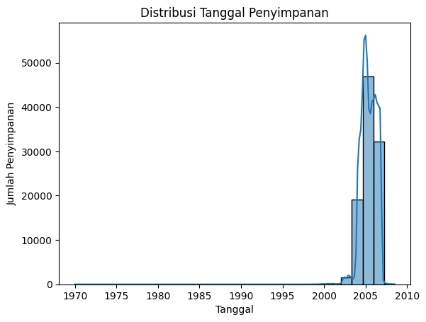

```python
sns.histplot(df['FirstSaveDate'], bins=30, kde=True)
plt.title('Distribusi Tanggal Penyimpanan')
plt.xlabel('Tanggal')
plt.ylabel('Jumlah Penyimpanan')
plt.show()
```

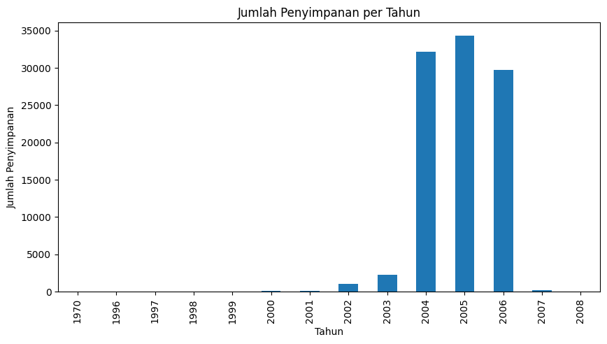

```python
yearly_counts = df.groupby('Year').size()
yearly_counts.plot(kind='bar', figsize=(10, 5), title='Jumlah Penyimpanan per Tahun')
plt.xlabel('Tahun')
plt.ylabel('Jumlah Penyimpanan')
plt.show()
```

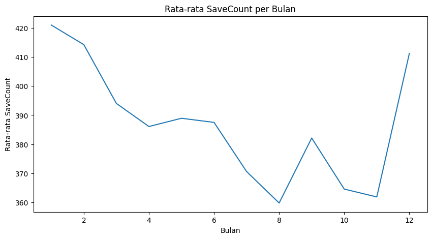

```python
monthly_avg_savecount = df.groupby('Month')['SaveCount'].mean()
monthly_avg_savecount.plot(kind='line', figsize=(10, 5), title='Rata-rata SaveCount per Bulan')
plt.xlabel('Bulan')
plt.ylabel('Rata-rata SaveCount')
plt.show()
```

These monthly trends suggest that bookmarking activity might align with global seasonal patterns, holiday seasons, and user behavior cycles. The peaks in January and December could be influenced by New Year resolutions, end-of-year reflections, or increased online engagement during holiday periods, while the dip in August might correspond to vacation seasons or lower online activity globally.

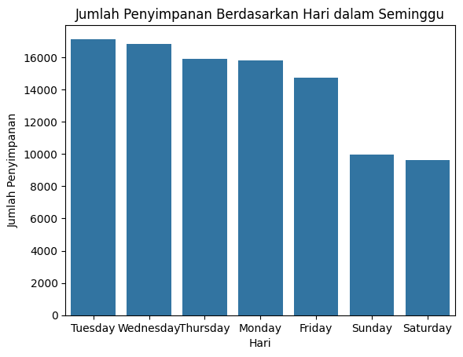

```python
day_counts = df['DayOfWeek'].value_counts()

sns.barplot(x=day_counts.index, y=day_counts.values)
plt.title('Jumlah Penyimpanan Berdasarkan Hari dalam Seminggu')
plt.xlabel('Hari')
plt.ylabel('Jumlah Penyimpanan')
plt.show()
```

This trend suggests that bookmarking activity is primarily driven by weekday routines, possibly related to work or academic tasks, with peak engagement mid-week. The drop during weekends indicates a shift in user focus towards leisure activities or reduced online productivity-related tasks.

```python
df.describe()
```

|  | SaveCount | FirstSaveDate | Count1 | Count2 | Count3 | Count4 | Count5 | Count6 | Count7 | Count8 | Count9 | Count10 | Year | Month |
| --- | --- | --- | --- | --- | --- | --- | --- | --- | --- | --- | --- | --- | --- | --- |
| count | 99983.000000 | 99983 | 99982.000000 | 99982.000000 | 99982.000000 | 99982.000000 | 99982.000000 | 99982.000000 | 99981.000000 | 99981.000000 | 99981.000000 | 99981.000000 | 99983.000000 | 99983.000000 |
| mean | 386.481442 | 2005-05-23 02:25:24.427152640 | 213.639235 | 146.856054 | 114.754236 | 93.784601 | 78.475616 | 65.406013 | 53.571239 | 36.853842 | 23.956692 | 19.672138 | 2004.893612 | 6.494544 |
| min | 0.000000 | 1970-01-01 00:00:00 | 2.000000 | 1.000000 | 1.000000 | 1.000000 | 1.000000 | 1.000000 | 1.000000 | 1.000000 | 1.000000 | 1.000000 | 1970.000000 | 1.000000 |
| 25% | 131.000000 | 2004-09-30 00:00:00 | 71.000000 | 48.000000 | 37.000000 | 30.000000 | 24.000000 | 20.000000 | 16.000000 | 11.000000 | 8.000000 | 7.000000 | 2004.000000 | 3.000000 |
| 50% | 190.000000 | 2005-05-08 00:00:00 | 106.000000 | 73.000000 | 56.000000 | 46.000000 | 38.000000 | 31.000000 | 25.000000 | 18.000000 | 13.000000 | 11.000000 | 2005.000000 | 7.000000 |
| 75% | 343.000000 | 2006-02-22 00:00:00 | 194.000000 | 134.000000 | 104.000000 | 84.000000 | 70.000000 | 58.000000 | 48.000000 | 33.000000 | 23.000000 | 20.000000 | 2006.000000 | 10.000000 |
| max | 47366.000000 | 2008-06-28 00:00:00 | 26263.000000 | 17536.000000 | 8810.000000 | 8047.000000 | 6938.000000 | 6880.000000 | 6586.000000 | 4704.000000 | 2287.000000 | 1705.000000 | 2008.000000 | 12.000000 |
| std | 875.764608 | NaN | 459.253761 | 316.640839 | 247.589144 | 207.117630 | 177.416021 | 152.484295 | 128.387468 | 89.270455 | 46.775353 | 37.465665 | 0.929854 | 3.497689 |

```python
df.isnull().sum()
```

```
URL              0
SaveCount        0
FirstSaveDate    0
Tag1             1
Count1           1
Tag2             1
Count2           1
Tag3             1
Count3           1
Tag4             1
Count4           1
Tag5             1
Count5           1
Tag6             1
Count6           1
Tag7             3
Count7           2
Tag8             2
Count8           2
Tag9             2
Count9           2
Tag10            2
Count10          2
Year             0
Month            0
DayOfWeek        0
dtype: int64
```

```python
missing_percentage = df.isnull().sum() / len(df) * 100
print(missing_percentage)
```

```
URL              0.000000
SaveCount        0.000000
FirstSaveDate    0.000000
Tag1             0.001000
Count1           0.001000
Tag2             0.001000
Count2           0.001000
Tag3             0.001000
Count3           0.001000
Tag4             0.001000
Count4           0.001000
Tag5             0.001000
Count5           0.001000
Tag6             0.001000
Count6           0.001000
Tag7             0.003001
Count7           0.002000
Tag8             0.002000
Count8           0.002000
Tag9             0.002000
Count9           0.002000
Tag10            0.002000
Count10          0.002000
Year             0.000000
Month            0.000000
DayOfWeek        0.000000
dtype: float64
```

The low percentage of missing data allowed for straightforward preprocessing by removing incomplete rows, ensuring the dataset remained intact and reliable for analysis without introducing bias or requiring complex imputation techniques.

```python
df.dropna(inplace=True)
```

```python
for i in range(1, 11):
    print(df[f'Tag{i}'].value_counts().head(10))
    print("")
```

```
Tag1
design         2726
music          2003
blog           1907
css            1677
photography    1517
linux          1485
art            1272
games          1267
video          1183
javascript     1091
Name: count, dtype: int64

Tag2
blog           2519
design         2516
software       2243
programming    1877
reference      1286
webdesign      1239
art            1039
linux           963
video           957
tutorial        935
Name: count, dtype: int64

Tag3
design         2334
software       2060
reference      1963
programming    1861
webdesign      1589
blog           1573
tools          1505
tutorial       1384
howto          1127
art             908
Name: count, dtype: int64

Tag4
```

[output cut: 74 more lines]

```
software       1142
Name: count, dtype: int64

Tag10
tools          1643
web            1552
reference      1492
development    1475
free           1186
howto          1186
imported       1141
design         1045
blog            981
software        975
Name: count, dtype: int64
```

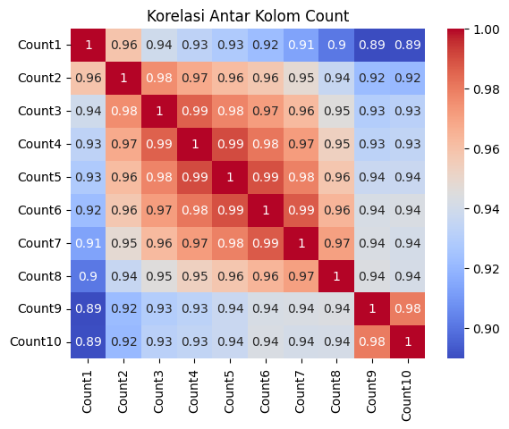

```python
count_cols = [f'Count{i}' for i in range(1, 11)]
corr = df[count_cols].corr()
sns.heatmap(corr, annot=True, cmap='coolwarm')
plt.title("Korelasi Antar Kolom Count")
plt.show()
```

The high correlation indicates the potential for dimensionality reduction techniques, such as TF-IDF or PCA, to improve computational efficiency.

```python
for i in range(1, 11):
    print(df.groupby(f'Tag{i}')['SaveCount'].mean().sort_values(ascending=False).head(10))
    print("")
```

```
Tag1
lorem          10943.000000
Encryption      6447.000000
Reviews         6198.000000
twitter         5894.666667
Goals           5454.000000
Ikea            4963.000000
speedtest       4907.200000
passwords       4598.250000
Bookmarking     4015.000000
shortcut:wp     3679.000000
Name: SaveCount, dtype: float64

Tag2
Coupons         11185.000000
netvibes        10543.666667
handmade         9189.000000
pedometer        7552.000000
Digg             7465.333333
cnn              6566.666667
powertoys        6232.000000
registration     6071.333333
creditreport     5919.000000
igoogle          5396.000000
Name: SaveCount, dtype: float64

Tag3
loading       16179.0
secrets       15869.0
GUARDIAN       8197.0
OpenOffice     7038.0
spiegel        6048.0
woot           5929.0
cheats         4917.0
sIFR           4870.0
Test           4756.0
Assessment     4692.0
Name: SaveCount, dtype: float64

Tag4
```

[output cut: 74 more lines]

```
how               9752.666667
Name: SaveCount, dtype: float64

Tag10
boolean          24482.000000
Bugmenot         15721.000000
Traductor        11862.000000
Reddit           11230.000000
Popular          11020.333333
microblogging    10148.000000
seats             9980.000000
urban_legends     8933.000000
CODING            8251.000000
deviantart        7904.666667
Name: SaveCount, dtype: float64
```

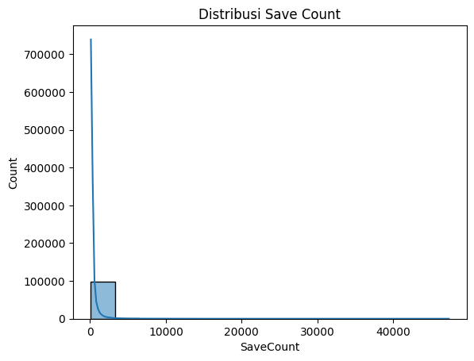

```python
sns.histplot(df['SaveCount'], bins=15, kde=True)
plt.title("Distribusi Save Count")
plt.show()
```

```python
print(df['URL'].nunique(), len(df))
```

```
99980 99980
```

```python
df.head()
```

|  | URL | SaveCount | FirstSaveDate | Tag1 | Count1 | Tag2 | Count2 | Tag3 | Count3 | Tag4 | ... | Count7 | Tag8 | Count8 | Tag9 | Count9 | Tag10 | Count10 | Year | Month | DayOfWeek |
| --- | --- | --- | --- | --- | --- | --- | --- | --- | --- | --- | --- | --- | --- | --- | --- | --- | --- | --- | --- | --- | --- |
| 0 | http://boingboing.net/ | 11053 | 2002-11-15 | blog | 5018.0 | news | 2763.0 | culture | 2542.0 | blogs | ... | 1436.0 | daily | 1016.0 | art | 641.0 | geek | 464.0 | 2002 | 11 | Friday |
| 1 | http://slashdot.org/ | 33365 | 1999-04-23 | news | 17683.0 | technology | 11477.0 | tech | 6606.0 | geek | ... | 3403.0 | daily | 2602.0 | imported | 1534.0 | Blogs | 1134.0 | 1999 | 4 | Friday |
| 2 | http://del.icio.us/ | 21767 | 2003-09-21 | del.icio.us | 3918.0 | bookmarks | 2873.0 | social | 2089.0 | delicious | ... | 1306.0 | bookmarking | 914.0 | community | 609.0 | tools | 478.0 | 2003 | 9 | Sunday |
| 3 | http://www.michaelbach.de/ot/index.html | 3264 | 2003-09-14 | optical | 1207.0 | illusion | 1090.0 | illusions | 900.0 | science | ... | 372.0 | graphics | 215.0 | design | 169.0 | education | 150.0 | 2003 | 9 | Sunday |
| 4 | http://memepool.com/ | 668 | 2003-09-14 | blog | 273.0 | meme | 175.0 | links | 171.0 | humor | ... | 80.0 | news | 72.0 | culture | 42.0 | web | 41.0 | 2003 | 9 | Sunday |

5 rows × 26 columns

```python
label_encoder = LabelEncoder()

def ubah_categorical(df,columns):
    for col in columns:
        df[col] = label_encoder.fit_transform(df[col])

df['URL_encoded'] = label_encoder.fit_transform(df['URL'])
df['DayOfWeek'] = label_encoder.fit_transform(df['DayOfWeek'])
col = [col for col in cat_cols if col != 'URL']
ubah_categorical(df,col)
df.head()
```

|  | URL | SaveCount | FirstSaveDate | Tag1 | Count1 | Tag2 | Count2 | Tag3 | Count3 | Tag4 | ... | Tag8 | Count8 | Tag9 | Count9 | Tag10 | Count10 | Year | Month | DayOfWeek | URL_encoded |
| --- | --- | --- | --- | --- | --- | --- | --- | --- | --- | --- | --- | --- | --- | --- | --- | --- | --- | --- | --- | --- | --- |
| 0 | http://boingboing.net/ | 11053 | 350 | 2578 | 5018.0 | 6271 | 2763.0 | 3805 | 2542.0 | 2940 | ... | 3982 | 1016.0 | 3690 | 641.0 | 6707 | 464.0 | 2002 | 11 | 0 | 3389 |
| 1 | http://slashdot.org/ | 33365 | 14 | 4905 | 17683.0 | 8197 | 11477.0 | 9068 | 6606.0 | 5054 | ... | 3982 | 2602.0 | 6803 | 1534.0 | 454 | 1134.0 | 1999 | 4 | 0 | 24711 |
| 2 | http://del.icio.us/ | 21767 | 615 | 3184 | 3918.0 | 2909 | 2873.0 | 8586 | 2089.0 | 3973 | ... | 3094 | 914.0 | 4701 | 609.0 | 11168 | 478.0 | 2003 | 9 | 3 | 6117 |
| 3 | http://www.michaelbach.de/ot/index.html | 3264 | 608 | 5027 | 1207.0 | 5111 | 1090.0 | 5541 | 900.0 | 8473 | ... | 5291 | 215.0 | 5152 | 169.0 | 5965 | 150.0 | 2003 | 9 | 3 | 68600 |
| 4 | http://memepool.com/ | 668 | 608 | 2578 | 273.0 | 5903 | 175.0 | 6148 | 171.0 | 5568 | ... | 6970 | 72.0 | 4977 | 42.0 | 11667 | 41.0 | 2003 | 9 | 3 | 17686 |

5 rows × 27 columns

```python
scaler = StandardScaler()
all = [col for col in df.columns if col != 'URL']
def ubah_numerik(df, columns):
    for col in columns:
        df[col] = scaler.fit_transform(df[[col]])

ubah_numerik(df, all)
df.head()
```

|  | URL | SaveCount | FirstSaveDate | Tag1 | Count1 | Tag2 | Count2 | Tag3 | Count3 | Tag4 | ... | Tag8 | Count8 | Tag9 | Count9 | Tag10 | Count10 | Year | Month | DayOfWeek | URL_encoded |
| --- | --- | --- | --- | --- | --- | --- | --- | --- | --- | --- | --- | --- | --- | --- | --- | --- | --- | --- | --- | --- | --- |
| 0 | http://boingboing.net/ | 12.179552 | -2.672818 | -0.874664 | 10.461184 | 0.392012 | 8.262145 | -0.793391 | 9.803481 | -1.145902 | ... | -0.725984 | 10.968314 | -0.939668 | 13.191638 | -0.068001 | 11.859605 | -3.111900 | 1.288127 | -1.504082 | -1.614612 |
| 1 | http://slashdot.org/ | 37.656503 | -3.697857 | 0.506127 | 38.038403 | 1.213622 | 35.782192 | 1.206317 | 26.217715 | -0.370792 | ... | -0.725984 | 28.734560 | 0.126301 | 32.282902 | -2.055208 | 29.742656 | -6.338217 | -0.713202 | -1.504082 | -0.875848 |
| 2 | http://del.icio.us/ | 24.413330 | -1.864380 | -0.515077 | 8.066005 | -1.042180 | 8.609541 | 1.023178 | 7.973843 | -0.767147 | ... | -1.064089 | 9.825718 | -0.593476 | 12.507517 | 1.349707 | 12.233281 | -2.036461 | 0.716319 | -0.072441 | -1.520092 |
| 3 | http://www.michaelbach.de/ot/index.html | 3.285685 | -1.885735 | 0.578519 | 2.162977 | -0.102831 | 2.978574 | -0.133788 | 3.171549 | 0.882804 | ... | -0.227585 | 1.995576 | -0.439043 | 3.100847 | -0.303809 | 3.478593 | -2.036461 | 0.716319 | -0.072441 | 0.644816 |
| 4 | http://memepool.com/ | 0.321443 | -1.885735 | -0.874664 | 0.129252 | 0.235027 | 0.088875 | 0.096845 | 0.227165 | -0.182331 | ... | 0.411692 | 0.393701 | -0.498967 | 0.385741 | 1.508290 | 0.569261 | -2.036461 | 0.716319 | -0.072441 | -1.119250 |

5 rows × 27 columns

```python
X = df[[col for col in df.columns if col not in ['URL', 'URL_encoded']]]
y = df['URL_encoded']

X_train, X_test, y_train, y_test = train_test_split(X, y, test_size=0.2, random_state=42)
```

# Content - Based Filtering

```python
# convert all columns to strings and join them into a single string for each row
feature = X.astype(str).apply(lambda x: ' '.join(x), axis=1)

# tfidf Vectorization
tfidf = TfidfVectorizer()
tfidf_matrix = tfidf.fit_transform(feature)

# nearest neighbors modeling
model = NearestNeighbors(n_neighbors=6, metric='cosine', algorithm='brute')
model.fit(tfidf_matrix)

# recomendation function
def recommend(url, df):
    if url not in df['URL'].values:
        return f"Error: URL '{url}' not found in the dataset."

    idx = df.index[df['URL'] == url][0]
    distances, indices = model.kneighbors(tfidf_matrix[idx])
    recommended_indices = indices[0][1:]
    return df.iloc[recommended_indices]['URL'].values

recommended_urls = recommend('http://www.elearningpapers.eu/index.php?page=home', df)
print("Recommended URLs:")
for url in recommended_urls:
    print(url)
```

```
Recommended URLs:
http://www.beatnikpad.com/archives/2006/06/04/firefox-1504
http://cooliris.com/
https://addons.mozilla.org/firefox/951/
http://labs.unoh.net/2006/10/web20firefox.html
http://69.90.152.144/collab/GreaseMonkeyUserScripts
```

# Neural Network Approach

```python
# input layer
savecount_input = Input(shape=(1,), name='savecount_input')
firstsavedate_input = Input(shape=(1,), name='firstsavedate_input')
year_input = Input(shape=(1,), name='year_input')
month_input = Input(shape=(1,), name='month_input')
dayofweek_input = Input(shape=(1,), name='dayofweek_input')
tag_inputs = [Input(shape=(1,), name=f'tag{i}_input') for i in range(1, 11)]
count_inputs = [Input(shape=(1,), name=f'count{i}_input') for i in range(1, 11)]

# flatten the input layer
savecount_vector = Flatten()(savecount_input)
firstsavedate_vector = Flatten()(firstsavedate_input)
year_vector = Flatten()(year_input)
month_vector = Flatten()(month_input)
dayofweek_vector = Flatten()(dayofweek_input)
tag_vectors = [Flatten()(tag_input) for tag_input in tag_inputs]  # Directly use encoded values
count_vectors = [Flatten()(count_input) for count_input in count_inputs]

# merge all the input features that already flatted
concatenated = Concatenate()([
    savecount_vector, firstsavedate_vector, year_vector, month_vector, dayofweek_vector,
    *tag_vectors, *count_vectors
])

# dense layer
dense1 = Dense(128, activation='relu')(concatenated)
dense2 = Dense(64, activation='relu')(dense1)
output = Dense(1)(dense2)

# modeling
model = Model(inputs=[savecount_input, firstsavedate_input, year_input, month_input, dayofweek_input] + tag_inputs + count_inputs, outputs=output)
model.compile(optimizer=Adam(learning_rate=0.001), loss='mean_squared_error')

# training model from the history
history = model.fit(
    [X_train['SaveCount'], X_train['FirstSaveDate'], X_train['Year'], X_train['Month'], X_train['DayOfWeek']] +
    [X_train[f'Tag{i}'] for i in range(1, 11)] + [X_train[f'Count{i}'] for i in range(1, 11)],
    y_train,
    validation_data=(
        [X_test['SaveCount'], X_test['FirstSaveDate'], X_test['Year'], X_test['Month'], X_test['DayOfWeek']] +
        [X_test[f'Tag{i}'] for i in range(1, 11)] + [X_test[f'Count{i}'] for i in range(1, 11)],
        y_test
    ),
    epochs=10,
    batch_size=128
)

# make prediction
y_pred = model.predict(
    [X_test['SaveCount'], X_test['FirstSaveDate'], X_test['Year'], X_test['Month'], X_test['DayOfWeek']] +
    [X_test[f'Tag{i}'] for i in range(1, 11)] + [X_test[f'Count{i}'] for i in range(1, 11)]
)

rmse = np.sqrt(mean_squared_error(y_test, y_pred))
print(f"RMSE: {rmse:.4f}")
```

```
625/625 ━━━━━━━━━━━━━━━━━━━━ 9s 7ms/step - loss: 1.0131 - val_loss: 1.0001
625/625 ━━━━━━━━━━━━━━━━━━━━ 4s 6ms/step - loss: 0.9932 - val_loss: 0.9890
625/625 ━━━━━━━━━━━━━━━━━━━━ 4s 6ms/step - loss: 0.9803 - val_loss: 0.9877
625/625 ━━━━━━━━━━━━━━━━━━━━ 4s 7ms/step - loss: 0.9790 - val_loss: 0.9890
625/625 ━━━━━━━━━━━━━━━━━━━━ 4s 6ms/step - loss: 0.9762 - val_loss: 0.9918
625/625 ━━━━━━━━━━━━━━━━━━━━ 4s 6ms/step - loss: 0.9764 - val_loss: 0.9895
625/625 ━━━━━━━━━━━━━━━━━━━━ 4s 6ms/step - loss: 0.9740 - val_loss: 0.9883
625/625 ━━━━━━━━━━━━━━━━━━━━ 4s 7ms/step - loss: 0.9756 - val_loss: 0.9906
625/625 ━━━━━━━━━━━━━━━━━━━━ 4s 6ms/step - loss: 0.9643 - val_loss: 0.9877
625/625 ━━━━━━━━━━━━━━━━━━━━ 4s 6ms/step - loss: 0.9705 - val_loss: 0.9896
625/625 ━━━━━━━━━━━━━━━━━━━━ 5s 7ms/step
RMSE: 0.9948
```

```python
model.summary()
```

```
Model: "functional_4"
```

```
┏━━━━━━━━━━━━━━━━━━━━━━━━━━━━━━━┳━━━━━━━━━━━━━━━━━━━━━━━━━━━┳━━━━━━━━━━━━━━━━━┳━━━━━━━━━━━━━━━━━━━━━━━━━━━━┓
┃ Layer (type)                  ┃ Output Shape              ┃         Param # ┃ Connected to               ┃
┡━━━━━━━━━━━━━━━━━━━━━━━━━━━━━━━╇━━━━━━━━━━━━━━━━━━━━━━━━━━━╇━━━━━━━━━━━━━━━━━╇━━━━━━━━━━━━━━━━━━━━━━━━━━━━┩
│ savecount_input (InputLayer)  │ (None, 1)                 │               0 │ -                          │
├───────────────────────────────┼───────────────────────────┼─────────────────┼────────────────────────────┤
│ firstsavedate_input           │ (None, 1)                 │               0 │ -                          │
│ (InputLayer)                  │                           │                 │                            │
├───────────────────────────────┼───────────────────────────┼─────────────────┼────────────────────────────┤
│ year_input (InputLayer)       │ (None, 1)                 │               0 │ -                          │
├───────────────────────────────┼───────────────────────────┼─────────────────┼────────────────────────────┤
│ month_input (InputLayer)      │ (None, 1)                 │               0 │ -                          │
├───────────────────────────────┼───────────────────────────┼─────────────────┼────────────────────────────┤
│ dayofweek_input (InputLayer)  │ (None, 1)                 │               0 │ -                          │
├───────────────────────────────┼───────────────────────────┼─────────────────┼────────────────────────────┤
│ tag1_input (InputLayer)       │ (None, 1)                 │               0 │ -                          │
├───────────────────────────────┼───────────────────────────┼─────────────────┼────────────────────────────┤
│ tag2_input (InputLayer)       │ (None, 1)                 │               0 │ -                          │
├───────────────────────────────┼───────────────────────────┼─────────────────┼────────────────────────────┤
│ tag3_input (InputLayer)       │ (None, 1)                 │               0 │ -                          │
├───────────────────────────────┼───────────────────────────┼─────────────────┼────────────────────────────┤
│ tag4_input (InputLayer)       │ (None, 1)                 │               0 │ -                          │
├───────────────────────────────┼───────────────────────────┼─────────────────┼────────────────────────────┤
│ tag5_input (InputLayer)       │ (None, 1)                 │               0 │ -                          │
├───────────────────────────────┼───────────────────────────┼─────────────────┼────────────────────────────┤
│ tag6_input (InputLayer)       │ (None, 1)                 │               0 │ -                          │
├───────────────────────────────┼───────────────────────────┼─────────────────┼────────────────────────────┤
│ tag7_input (InputLayer)       │ (None, 1)                 │               0 │ -                          │
├───────────────────────────────┼───────────────────────────┼─────────────────┼────────────────────────────┤
│ tag8_input (InputLayer)       │ (None, 1)                 │               0 │ -                          │
├───────────────────────────────┼───────────────────────────┼─────────────────┼────────────────────────────┤
│ tag9_input (InputLayer)       │ (None, 1)                 │               0 │ -                          │
├───────────────────────────────┼───────────────────────────┼─────────────────┼────────────────────────────┤
│ tag10_input (InputLayer)      │ (None, 1)                 │               0 │ -                          │
├───────────────────────────────┼───────────────────────────┼─────────────────┼────────────────────────────┤
│ count1_input (InputLayer)     │ (None, 1)                 │               0 │ -                          │
├───────────────────────────────┼───────────────────────────┼─────────────────┼────────────────────────────┤
│ count2_input (InputLayer)     │ (None, 1)                 │               0 │ -                          │
├───────────────────────────────┼───────────────────────────┼─────────────────┼────────────────────────────┤
│ count3_input (InputLayer)     │ (None, 1)                 │               0 │ -                          │
├───────────────────────────────┼───────────────────────────┼─────────────────┼────────────────────────────┤
```

[output cut: 81 more lines]

```
│                               │                           │                 │ flatten_117[0][0],         │
│                               │                           │                 │ flatten_118[0][0],         │
│                               │                           │                 │ flatten_119[0][0],         │
│                               │                           │                 │ flatten_120[0][0],         │
│                               │                           │                 │ flatten_121[0][0],         │
│                               │                           │                 │ flatten_122[0][0],         │
│                               │                           │                 │ flatten_123[0][0],         │
│                               │                           │                 │ flatten_124[0][0]          │
├───────────────────────────────┼───────────────────────────┼─────────────────┼────────────────────────────┤
│ dense_12 (Dense)              │ (None, 128)               │           3,328 │ concatenate_4[0][0]        │
├───────────────────────────────┼───────────────────────────┼─────────────────┼────────────────────────────┤
│ dense_13 (Dense)              │ (None, 64)                │           8,256 │ dense_12[0][0]             │
├───────────────────────────────┼───────────────────────────┼─────────────────┼────────────────────────────┤
│ dense_14 (Dense)              │ (None, 1)                 │              65 │ dense_13[0][0]             │
└───────────────────────────────┴───────────────────────────┴─────────────────┴────────────────────────────┘
```

```
 Total params: 34,949 (136.52 KB)
```

```
 Trainable params: 11,649 (45.50 KB)
```

```
 Non-trainable params: 0 (0.00 B)
```

```
 Optimizer params: 23,300 (91.02 KB)
```